# IE 360 Homework #2

## Introduction

Mehmet Yusuf Kaya IE-360 06.12.2020

The value of the money of a specific currency strongly depends on confidence of that country. Developed countries such as European Union countries, U.S.A and Canada gives reliance to almost every people in the world. Whatever happens in the world, they probably will be in a better situation than other countries. Financial markets know that if there will be an extra ordinary situation like war or pandemic etc. these countries might handle the situation easier than other countries because of their infrastructure, health system, military, technology, in short, overall economic power. That’s why we call them developed.

Therefore most of the countries are doing business with developed countries’ currency like USD or EUR. Because the overall economic activity in the whole world has been going heavily on dollar and euro their volume is incredibly high compared to other currency and it contributes their stability and trustworthiness. In addition the interest rate of USD and EUR is generally below %2.

In contrast in emerging countries like Turkey the currency and economic parameters are much more volatile because these parameters depend on Turkey’s economic situation and language. Whenever Turkey makes structural reforms or talks about reforms, the foreign investors believe that Turkey is going to develop so they invest in Turkey, its stock market or so. The same thing happens when Turkey restricts media and freedom of thought or corrupts the judicial system; investors take their money back and economic activity gets slower.

Thus far we know that power of Turkish Lira against dollar heavily depends on some structural parameters in Turkey. Now I am going to investigate the relationship between BIST100 index and USD/TRY rate. The stock price of a specific company depends on the company’s financial situation. Most of the companies in Turkey have business relationships with abroad so they have USD debt(They are exporting and importing). If the USD/TRY rate decreases I expect that BIST100 would increase because companies’ debt in terms of TL would decrease and their financial situation would be better.

The second relationship is between interest rate of deposit money and USD/TRY rate. If you are an investor and you want to make an investment in Turkey(it could be on real sector or financial markets) the first thing to consider before investment is to look at the interest rates. Because if you are holding money in dollar instead of TL you imply that USD/TRY rate will be higher more than interest rate. Therefore if the interest rate increases people are tend to buy TL instead of dollar to enjoy the interest rate with zero risk.

In this study I am going to analyze the question : “Are there any correlation, or to what extent, between the interest rate, USD/TRY rate and BIST100 index in Turkey?” To answer this question I will use the interest rate, USD/TRY rate and BIST 100 index data between 2012-2018. Before deep diving into the analysis part it is important to mention two important things. First, interest rate is determined by TCMB so the dynamic of interest rate is a little bit different than other parameters. Second, these parameters are mocroeconomic parameters hence there are tons of parameters also speculations that is impacting BIST100 index and USD/TRY rate but the scope of this work is limited with some basic parameters.

## Data Analysis

In this analysis all the data used is taken from EVDS website. Before analyzing, data manipulation is vital to arrange format and scale of the data correspondingly. It generally takes much time and effort. However, in this study datas have similar forms because they were taken from the same sources. It makes the analysis simpler.

```python
import pandas as pd
import numpy as np
import seaborn as sns
import matplotlib.pyplot as plt
import statsmodels as stat
from datetime import datetime
from scipy import stats
```

```python
##importing the data which is taken from EVDS web-site.
df = pd.read_excel(r'/Users/mehmetyusufkaya/Desktop/boun/ie360/hw#2/data.xlsx')
```

```python
##format arrangement
df1= pd.to_datetime(df['Tarih'],format = '%d-%m-%Y')
df["Tarih"]=df1
```

```python
##getting different dataframes to analyze individually
bistData = df[["Tarih","bist100"]]
usdData = df[["Tarih","usdtry"]]
faizData = df[["Tarih","faiz"]]
```

```python
##data manipulation function. makes it easy to classify the data by year.
def func (df , year):
    y = int (year)
    y = y+1
    year1 = str(y)
    df2 = df[(df["Tarih"]<year1) & (df["Tarih"]>year)]
    return df2
```

```python
df2012 = func(df,"2012")
#
bist2012 = func(bistData,"2012")
#
usd2012 = func(usdData,"2012")
#
faiz2012 = func(faizData,"2012")
```

## Visualization of datas on yearly basis

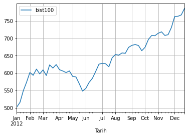

[figure not shown]

[figure not shown]

[figure not shown]

[figure not shown]

[figure not shown]

[figure not shown]

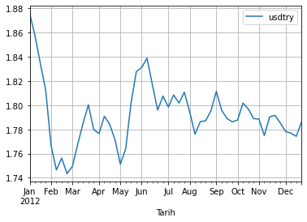

[figure not shown]

[figure not shown]

[figure not shown]

[figure not shown]

[9 more figures not shown]

```python
bist2012.plot(x="Tarih",grid=True)
#
usd2012.plot(x="Tarih",grid=True)
#
faiz2012.plot(x="Tarih",grid=True)
```

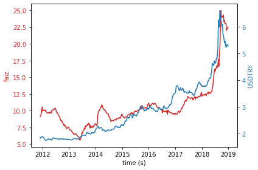

```python
##to see correlation we should look at the datas in the same graph with different scales.

fig, ax1 = plt.subplots()

color = 'tab:red'
ax1.set_xlabel('time (s)')
ax1.set_ylabel('faiz', color=color)
ax1.plot(faizData["Tarih"], faizData["faiz"], color=color)
ax1.tick_params(axis='y', labelcolor=color)

ax2 = ax1.twinx()  # instantiate a second axes that shares the same x-axis

color = 'tab:blue'
ax2.set_ylabel('USDTRY', color=color)  # we already handled the x-label with ax1
ax2.plot(usdData["Tarih"], usdData["usdtry"], color=color)
ax2.tick_params(axis='y', labelcolor=color)

fig.tight_layout()  # otherwise the right y-label is slightly clipped
plt.show()
```

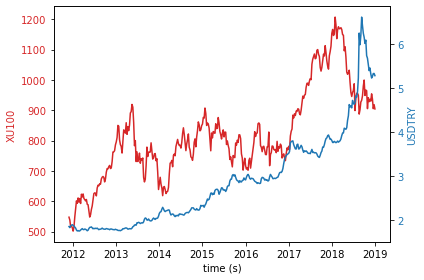

```python
##to see correlation we should look at the datas in the same graph with different scales.
fig2, ax3 = plt.subplots()

color = 'tab:red'
ax3.set_xlabel('time (s)')
ax3.set_ylabel('XU100', color=color)
ax3.plot(bistData["Tarih"], bistData["bist100"], color=color)
ax3.tick_params(axis='y', labelcolor=color)

ax4 = ax3.twinx()  # instantiate a second axes that shares the same x-axis

color = 'tab:blue'
ax4.set_ylabel('USDTRY', color=color)  # we already handled the x-label with ax1
ax4.plot(usdData["Tarih"], usdData["usdtry"], color=color)
ax4.tick_params(axis='y', labelcolor=color)

fig2.tight_layout()  # otherwise the right y-label is slightly clipped
plt.show()
```

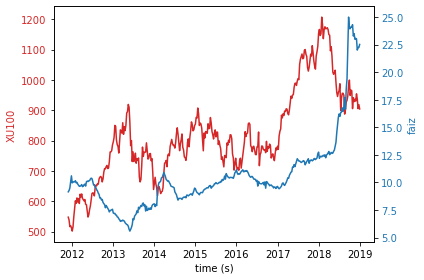

```python
##to see correlation we should look at the datas in the same graph with different scales.

fig3, ax5 = plt.subplots()

color = 'tab:red'
ax5.set_xlabel('time (s)')
ax5.set_ylabel('XU100', color=color)
ax5.plot(bistData["Tarih"], bistData["bist100"], color=color)
ax5.tick_params(axis='y', labelcolor=color)

ax6 = ax5.twinx()  # instantiate a second axes that shares the same x-axis

color = 'tab:blue'
ax6.set_ylabel('faiz', color=color)  # we already handled the x-label with ax1
ax6.plot(faizData["Tarih"], faizData["faiz"], color=color)
ax6.tick_params(axis='y', labelcolor=color)

fig3.tight_layout()  # otherwise the right y-label is slightly clipped
plt.show()
```

```python
corrmat = df.corr()
corrmat #correlation coefficients of the bulk data
```

|  | bist100 | usdtry | faiz |
| --- | --- | --- | --- |
| bist100 | 1.000000 | 0.662487 | 0.430353 |
| usdtry | 0.662487 | 1.000000 | 0.874801 |
| faiz | 0.430353 | 0.874801 | 1.000000 |

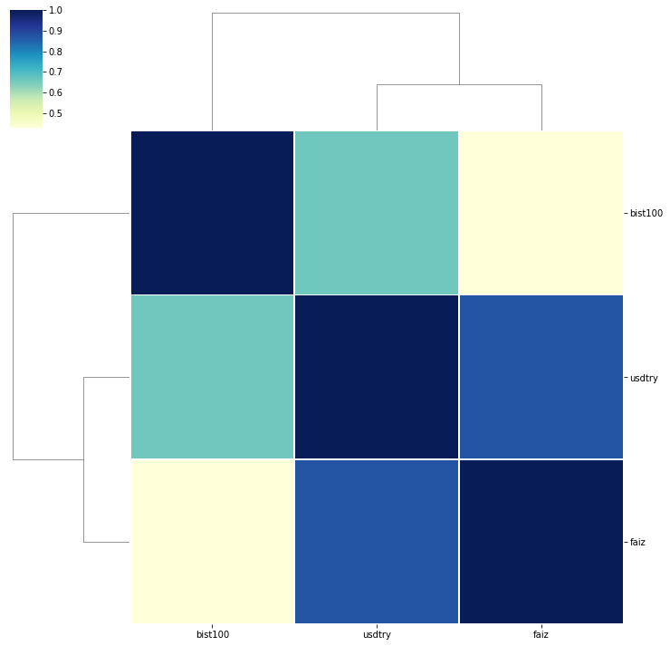

```python
#correlation matrix to visualize the coefficients.
cg = sns.clustermap(corrmat, cmap ="YlGnBu", linewidths = 0.8);
plt.setp(cg.ax_heatmap.yaxis.get_majorticklabels(), rotation = 0)

cg
```

```python
corr2012 = df2012.corr()
corr2013 = df2013.corr()
corr2014 = df2014.corr()
corr2015 = df2015.corr()
corr2016 = df2016.corr()
corr2017 = df2017.corr()
corr2018 = df2018.corr()
```

### Correlation Coefficient Matrix (Yearly 2012-2018)

```python
corr_data = [corr2012,corr2013,corr2014,corr2015,corr2016,corr2017,corr2018]
corr_data
```

```
[          bist100    usdtry      faiz
 bist100  1.000000 -0.368107 -0.908731
 usdtry  -0.368107  1.000000  0.200255
 faiz    -0.908731  0.200255  1.000000,
           bist100    usdtry      faiz
 bist100  1.000000 -0.744381 -0.703474
 usdtry  -0.744381  1.000000  0.709943
 faiz    -0.703474  0.709943  1.000000,
           bist100    usdtry      faiz
 bist100  1.000000 -0.120507 -0.315315
 usdtry  -0.120507  1.000000 -0.183703
 faiz    -0.315315 -0.183703  1.000000,
           bist100    usdtry      faiz
 bist100  1.000000 -0.825739 -0.750967
 usdtry  -0.825739  1.000000  0.918470
 faiz    -0.750967  0.918470  1.000000,
           bist100    usdtry      faiz
 bist100  1.000000 -0.315402  0.127578
 usdtry  -0.315402  1.000000 -0.627899
 faiz     0.127578 -0.627899  1.000000,
           bist100    usdtry      faiz
 bist100  1.000000 -0.044122  0.925432
 usdtry  -0.044122  1.000000 -0.086214
 faiz     0.925432 -0.086214  1.000000,
           bist100    usdtry      faiz
 bist100  1.000000 -0.816602 -0.738155
 usdtry  -0.816602  1.000000  0.857365
 faiz    -0.738155  0.857365  1.000000]
```

## Interpretation of Data & Coefficients

*Correlation coefficients indicate that the correlation between datas is changing significantly. Therefore just looking the bulk data could not give insight to us. The deeper analysis is done by obtaining the yearly correlation coefficients.

*Also we see that a negative correlation between BIST100 and USD/TRY rate in most of the years. The coefficient is around -0.8 in some years which implies a strong negative correlation. It indicates that my hypothesis is corrected by the analysis.

*Between interest rate and BIST100 index there is not a straightforward relationship. It flactuates year by year and the movement seem to me random. Although some specific years we see strong positive correlation coefficient, we also see strong negative correlation coefficient some other years.

## Conclusion

After looking at the visualizations and correlation analysis we can conclude that

-Very important thing to mention is the inflation in that analysis. We know that the inflation in Turkey is around %6-%20 between 2011-2018. Therefore to achieve a better correlation the effect of inflation in FX rate and specifically in BIST100 index should be removed.

-Although the correlation coefficient is not that close to 1, some specific years we see that the correlation between interest rate and FX rate is around 0.7-0.9. Also after interest rate increases we see downward slope in FX rate. Hence it is possible to conclude that the interest rate may be arranged to control FX rate by TCMB.